# Migration Dynamics and Quality of Life Index

Welcome to our project page.

*Team BU-R-SEL*

[Selin DÜZEN](https://emu-hacettepe-analytics.github.io/emu660-spring2026-Selindznn/project.html)

[Burcu BARIŞ](https://emu-hacettepe-analytics.github.io/emu660-spring2026-burcubaris/project.html)

# 1. Project Overview and Scope

Migration is not merely the geographical displacement of individuals; it is also a reflection of economic pursuits, social opportunities, and structural quality in a region. In Turkey, the difference in development and living standards between provinces constitutes one of the primary dynamics of internal migration movements.

# 2. Data

## 2.1 Data Source

The datasets used in the project are:

1.Population size of the provinces

2.[Migration received by provinces according to the reason for migration](https://veriportali.tuik.gov.tr/api/tr/data/downloads?t=i&p=%2FMyiBh3DmS%2Bv%2BBjCf9%2BzPq%2B96lw8HZTF50uTl9jqBks%2BK5WE6sQNt%2Fqka0J5%2BImWGTGxKxiPcrz7kNG6I3rKkrLi%2B8mZkMkz9reke8%2BHd%2Fo%3D)

3.[Migration rates by provinces according to the reason for migration](https://veriportali.tuik.gov.tr/api/tr/data/downloads?t=i&p=%2FMyiBh3DmS%2Bv%2BBjCf9%2BzPq%2B96lw8HZTF50uTl9jqBks%2BK5WE6sQNt%2Fqka0J5%2BImWGTGxKxiPcrz7kNG6I3rKkrLi%2B8mZkMkz9reke8%2BHd%2Fo%3D)

4.[Net migration rate for provinces according to reasons for migration] Calculated as “Migration Outgoing - Migration Incoming”

5.[Life Index Rankings and Index Values by Province](https://veriportali.tuik.gov.tr/api/tr/data/downloads?t=i&p=5IS1p1Z%2Btvlc0qxFhZzbC9g6NOWXugwdILs8mAMegx5w5sIpUqxydG6%2B5%2FWn1HGIIXJVqd%2Fwn%2B78duD2fsK84VEREA5Sn4QY5oeOWRHZRvVYOaDudiOCwll9hFpmp5W)

In this study, the five datasets mentioned above were used, graphs were plotted, and the results were thoroughly analyzed.

## 2.2 General Information About Data

Our dataset tracks migration metrics across all 81 provinces of Turkiye from 2018 to 2024. It combines raw inbound/outbound migration figures with detailed columns explaining 12 different reasons for migration, cross-references them with the Turkish Statistical Institute’s (TUIK) comprehensive Life Index scores, and shows the relationships between them.

## 2.3 Reason of Choice

We chose this data because migration cannot be explained solely by economic factors. By combining net migration metrics with the multidimensional Life Index (which assesses health, education, security, and environment), we can reveal the relationship between internal migration in Turkiye and life indices.

## 2.4 Preprocessing

The net migration values are calculated using migration data received and given by provinces in different Excel spreadsheets and the char formatted values containing spaces in the data were updated to numeric values.

```r
#install.packages("ggplot2")
#install.packages("dplyr")
#install.packages("openxlsx")
#install.packages("readxl")

# 1. R'ın geçici işlemler için C diskinin altında temiz bir klasör kullanmasını sağlıyoruz
write("TMPDIR = C:\\", file = file.path(Sys.getenv("HOME"), ".Renviron"), append = TRUE)

# 2. Şimdi paketi tekrar yüklemeyi dene
#install.packages("writexl")
#install.packages("ggrepel")
library(ggplot2)
library(dplyr)
library(readxl)
library(writexl)
library(stringr)
library(forcats)
library(tidyr)
library(openxlsx)
library(ggplot2)
library(readxl)
library(dplyr)
library(ggrepel)
```

### 2.4.1. Calculating net migration values and creating a separate Excel file and checking and correcting numerical values.

```r
VerilenGoc <- read_excel("C:/emu660-spring2026-burcubaris/VerilenGoc.xlsx", col_names = TRUE)
AlinanGoc  <- read_excel("C:/emu660-spring2026-burcubaris/AlinanGoc.xlsx", col_names = TRUE)
toplam_sutun <- ncol(VerilenGoc)
fark_df <- VerilenGoc
for (i in 3:toplam_sutun) {
  v_clean <- as.character(VerilenGoc[[i]])
  v_clean <- str_replace_all(v_clean, "\\s", "")
  VerilenGoc[[i]] <- as.numeric(v_clean)
  a_clean <- as.character(AlinanGoc[[i]])
  a_clean <- str_replace_all(a_clean, "\\s", "")
  AlinanGoc[[i]] <- as.numeric(a_clean)
}
fark_df[, 3:toplam_sutun] <- VerilenGoc[, 3:toplam_sutun] - AlinanGoc[, 3:toplam_sutun]
for (i in 3:toplam_sutun) {
  fark_df[[i]] <- as.numeric(fark_df[[i]])
}
write_xlsx(fark_df, "C:/emu660-spring2026-burcubaris/NetGoc.xlsx")
print(VerilenGoc[, 3:toplam_sutun])
```

```
# A tibble: 574 × 13
   `Toplam\r\nTotal` Tayin / iş değişikliği\r\nAssignat…¹ İşe başlamak /\r\n i…²
               <dbl>                                <dbl>                  <dbl>
 1           2682673                               280980                 221022
 2             56108                                 5251                   4260
 3             21158                                 2069                   1663
 4             25035                                 2770                   2657
 5             30970                                 4427                   2483
 6             14446                                 1594                   1444
 7            150373                                18554                  11161
 8             71999                                 5522                   5242
 9             10400                                 1046                   1110
10             35832                                 2971                   3561
# ℹ 564 more rows
# ℹ abbreviated names:
#   ¹`Tayin / iş değişikliği\r\nAssignation /\r\n change of job`,
#   ²`İşe başlamak /\r\n iş bulmak\r\nStarting / finding a job`
# ℹ 10 more variables: `Eğitim\r\nEducation` <dbl>,
#   `Medeni durum değişikliği / ailevi nedenler\r\nChange of marital status / family\r\nrelated reasons` <dbl>,
#   `Daha iyi konut ve yaşam koşulları\r\n Better housing and living conditions` <dbl>, …
```

```r
yedek_veri <- VerilenGoc
orijinal_isimler <- colnames(yedek_veri)

colnames(yedek_veri) <- c("Yil", "Il", "Toplam_Miktar", paste0("Neden_", 1:(ncol(yedek_veri) - 3)))

toplam_satir_2024 <- yedek_veri[yedek_veri$Il == "Toplam-Total" & yedek_veri$Yil == 2024, ]

sadece_rakamlar <- as.numeric(toplam_satir_2024[1, 4:ncol(toplam_satir_2024)])

en_buyuk_indeks <- which.max(sadece_rakamlar)
en_buyuk_neden_adi <- orijinal_isimler[en_buyuk_indeks + 3]
en_buyuk_neden_adi <- gsub("\\r\\n.*", "", en_buyuk_neden_adi)

print(paste("En Buyuk Goc Nedeni:", en_buyuk_neden_adi))
```

```
[1] "En Buyuk Goc Nedeni: Hane / aile fertlerinden birine bağımlı göç"
```

```r
print(paste("Kisi Sayisi:", sadece_rakamlar[en_buyuk_indeks]))
```

```
[1] "Kisi Sayisi: 579507"
```

#2018-2024 Yılları Arasındaki İlk Üç Göç Nedeni Sıralaması

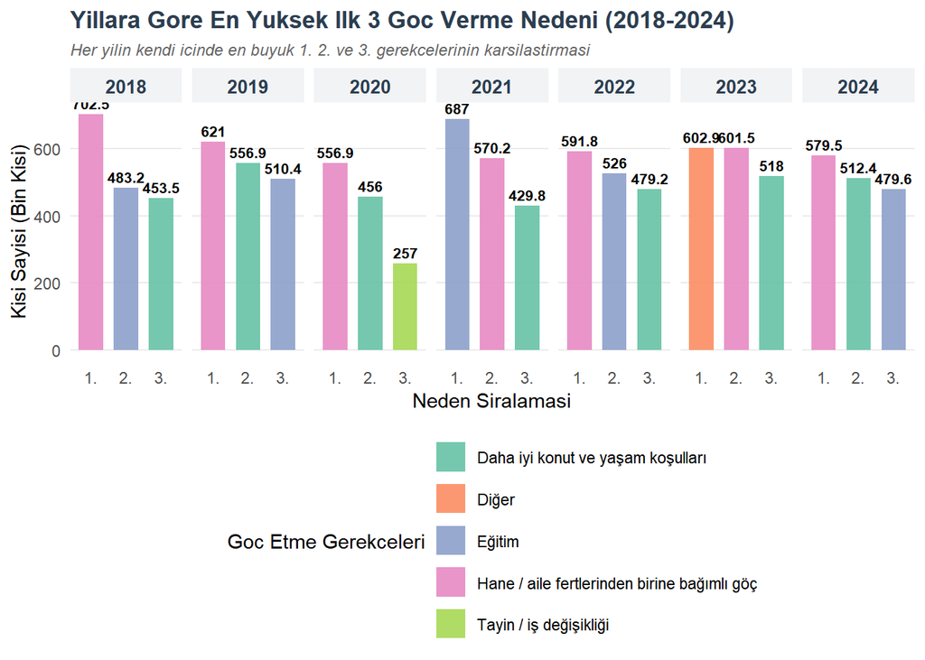

```r
library(ggplot2)
library(dplyr)
library(tidyr)

yedek_veri <- VerilenGoc
orijinal_isimler <- colnames(yedek_veri)

# 1. Sutun isimlerini R'in hata vermeyecegi guvenli kodlara ceviriyoruz
colnames(yedek_veri) <- c("Yil", "Il", "Toplam_Miktar", paste0("Neden_", 1:(ncol(yedek_veri) - 3)))

# 2. Sadece Turkiye geneli satirlarini filtreliyoruz
toplam_verisi <- yedek_veri[yedek_veri$Il == "Toplam-Total", ]

yillar <- sort(unique(toplam_verisi$Yil))
top3_verisi <- data.frame()

# 3. Her yil icin en buyuk ilk 3 nedeni dongu ile ayikliyoruz
for(y in yillar) {
  satir <- toplam_verisi[toplam_verisi$Yil == y, ]
  rakamlar <- as.numeric(satir[1, 4:ncol(satir)])

  # Buyukten kucuge siralayip ilk 3 indeks numarasini aliyoruz
  sirali_indeksler <- order(rakamlar, decreasing = TRUE)[1:3]

  for(i in 1:3) {
    idx <- sirali_indeksler[i]
    neden_metni <- orijinal_isimler[idx + 3]
    neden_metni <- gsub("\\r\\n.*", "", neden_metni) # Gizli karakter temizligi

    top3_verisi <- rbind(
      top3_verisi,
      data.frame(
        Yil = y,
        Sira = paste0(i, "."), # 1. 2. ve 3. ibaresi
        Goc_Nedeni = neden_metni,
        Kisi_Bin = rakamlar[idx] / 1000
      )
    )
  }
}

# 4. ESTETIK VE SIRALI COKLU PANEL GRAFIGINI CIZIYORUZ
ggplot(top3_verisi, aes(x = Sira, y = Kisi_Bin, fill = Goc_Nedeni)) +
  # Sutunlarimizi olusturuyoruz
  geom_col(width = 0.7, alpha = 0.9) +

  # Sutunlarin uzerine net bin kisi degerlerini yaziyoruz
  geom_text(
    aes(label = round(Kisi_Bin, 1)),
    vjust = -0.5,
    size = 2.8,
    fontface = "bold"
  ) +

  # Grafigi yillara gore yan yana panellere boluyoruz
  facet_wrap(~Yil, nrow = 1) +

  # Akademik ve net renk paleti
  scale_fill_brewer(palette = "Set2") +

  # Minimalist arka plan temasi
  theme_minimal(base_size = 11) +
  labs(
    title = "Yillara Gore En Yuksek Ilk 3 Goc Verme Nedeni (2018-2024)",
    subtitle = "Her yilin kendi icinde en buyuk 1. 2. ve 3. gerekcelerinin karsilastirmasi",
    x = "Neden Siralamasi",
    y = "Kisi Sayisi (Bin Kisi)",
    fill = "Goc Etme Gerekceleri"
  ) +
  theme(
    plot.title = element_text(face = "bold", size = 13, color = "#2c3e50"),
    plot.subtitle = element_text(size = 9, face = "italic", color = "gray40"),
    # Uzun aciklamalar alt alta temiz dursun diye lejanti alta aliyoruz
    legend.position = "bottom",
    panel.grid.minor = element_blank(),
    panel.grid.major.x = element_blank(),
    # Yil basliklarinin kutularini makale stilinde susluyoruz
    strip.background = element_rect(fill = "#f1f3f5", color = NA),
    strip.text = element_text(face = "bold", size = 10, color = "#2c3e50")
  ) +
  # Uzun cumlelerin tasmamasi icin aciklamalari tekli sutun yapiyoruz
  guides(fill = guide_legend(ncol = 1))
```

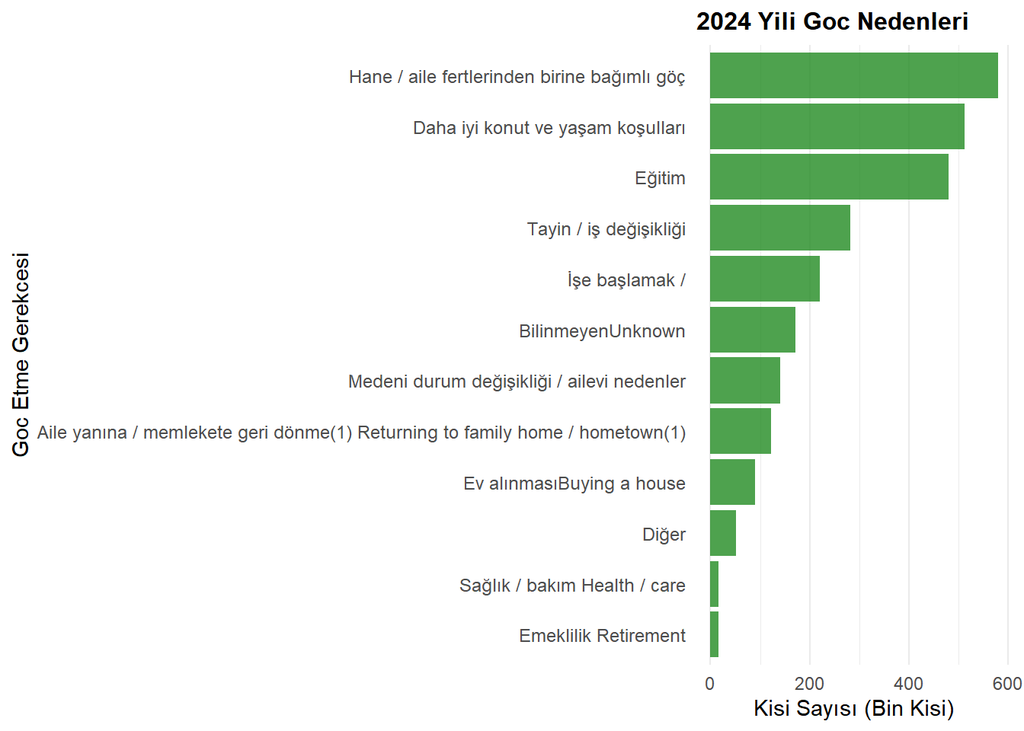

```r
library(ggplot2)
library(dplyr)
library(tidyr)

# 1. Veriyi hazırla ve filtrele (Sütun ismi yerine indeks numarası kullanıyoruz)
neden_verisi_2024 <- VerilenGoc %>%
  # 1. sütun Yıl (2024) ve 2. sütun İl (Toplam-Total) olan satırı seçiyoruz
  filter(.[[1]] == 2024 & .[[2]] == "Toplam-Total") %>%
  # İlk 3 sabit sütunu (Yıl, İl, Toplam) indeks numaralarıyla tablodan çıkarıyoruz
  select(-c(1, 2, 3)) %>%
  # Tabloyu ggplot'un anlayacağı uzun (long) formata çeviriyoruz
  pivot_longer(cols = everything(), names_to = "Goc_Nedeni", values_to = "Kisi_Sayisi") %>%
  mutate(Kisi_Sayisi_Bin = Kisi_Sayisi / 1000)

# Sütun isimlerindeki o sorun çıkaran \r\n karakterlerini temizliyoruz
neden_verisi_2024$Goc_Nedeni <- gsub("\\r\\n.*", "", neden_verisi_2024$Goc_Nedeni)

# 2. Grafiği Çiz (İller grafiğindeki sıkışma olmasın diye yazı boyutunu da ayarladık)
ggplot(neden_verisi_2024, aes(x = Kisi_Sayisi_Bin, y = reorder(Goc_Nedeni, Kisi_Sayisi_Bin))) +
  geom_col(fill = "forestgreen", alpha = 0.8) +
  theme_minimal() +
  labs(
    title = "2024 Yili Goc Nedenleri",
    x = "Kisi Sayısı (Bin Kisi)",
    y = "Goc Etme Gerekcesi"
  ) +
  theme(
    axis.text.y = element_text(size = 9), # Gerekçelerin yazı boyutu
    plot.title = element_text(face = "bold", size = 12),
    panel.grid.major.y = element_blank() # Yatay kalabalık çizgileri gizler
  )
```

If we look at the most recent data from 2024, we see that the main reasons for migration are family-based migration and the pursuit of better living conditions and education. The highest value for 2024 actually shows us that the population living in Turkey is family-oriented, which is not surprising. Second, we see that people are relocating in large numbers in search of better living conditions. Third, regarding education, we see that the factors of university and school continue to be among the foundations of internal migration in Turkiye.

### 2.4.2. Calculating net migration rate using population data of provinces and creating an Excel file.

```r
kaynak_yolu <- "C:/emu660-spring2026-burcubaris/NetGoc.xlsx"
hedef_yolu  <- "C:/emu660-spring2026-burcubaris/IlNufuslarii.xlsx"

df_kaynak <- read_excel(kaynak_yolu, col_names = TRUE)

NetGocVerisi <- df_kaynak[1:82, 3, drop = TRUE]
wb <- loadWorkbook(hedef_yolu)
writeData(wb, sheet = 1, x = "Net GC6C'", startCol = 3, startRow = 1, colNames = FALSE)
writeData(wb, sheet = 1, x = NetGocVerisi, startCol = 3, startRow = 2, colNames = FALSE)

saveWorkbook(wb, hedef_yolu, overwrite = TRUE)
```

# 3. Analysis

## 3.1 Exploratory Data Analysis

### 3.1.1. Changes in Total Migration Values by Year (2018-2024)

The changes in the total amount of migration over the years were shown graphically.

```r
grafik_verisi <- VerilenGoc[VerilenGoc[, 2] == "Toplam-Total", ]
print(grafik_verisi)
```

```
# A tibble: 7 × 15
  `Yıl\r\nYear` `İl\r\nProvince` `Toplam\r\nTotal` Tayin / iş değişikliği\r\nA…¹
          <dbl> <chr>                        <dbl>                         <dbl>
1          2024 Toplam-Total               2682673                        280980
2          2023 Toplam-Total               3450953                        320142
3          2022 Toplam-Total               2791156                        301335
4          2021 Toplam-Total               2777797                        265537
5          2020 Toplam-Total               2258726                        257027
6          2019 Toplam-Total               2806123                        262833
7          2018 Toplam-Total               3057606                        315849
# ℹ abbreviated name:
#   ¹`Tayin / iş değişikliği\r\nAssignation /\r\n change of job`
# ℹ 11 more variables:
#   `İşe başlamak /\r\n iş bulmak\r\nStarting / finding a job` <dbl>,
#   `Eğitim\r\nEducation` <dbl>,
#   `Medeni durum değişikliği / ailevi nedenler\r\nChange of marital status / family\r\nrelated reasons` <dbl>,
#   `Daha iyi konut ve yaşam koşulları\r\n Better housing and living conditions` <dbl>, …
```

```r
head(grafik_verisi)
```

```
# A tibble: 6 × 15
  `Yıl\r\nYear` `İl\r\nProvince` `Toplam\r\nTotal` Tayin / iş değişikliği\r\nA…¹
          <dbl> <chr>                        <dbl>                         <dbl>
1          2024 Toplam-Total               2682673                        280980
2          2023 Toplam-Total               3450953                        320142
3          2022 Toplam-Total               2791156                        301335
4          2021 Toplam-Total               2777797                        265537
5          2020 Toplam-Total               2258726                        257027
6          2019 Toplam-Total               2806123                        262833
# ℹ abbreviated name:
#   ¹`Tayin / iş değişikliği\r\nAssignation /\r\n change of job`
# ℹ 11 more variables:
#   `İşe başlamak /\r\n iş bulmak\r\nStarting / finding a job` <dbl>,
#   `Eğitim\r\nEducation` <dbl>,
#   `Medeni durum değişikliği / ailevi nedenler\r\nChange of marital status / family\r\nrelated reasons` <dbl>,
#   `Daha iyi konut ve yaşam koşulları\r\n Better housing and living conditions` <dbl>, …
```

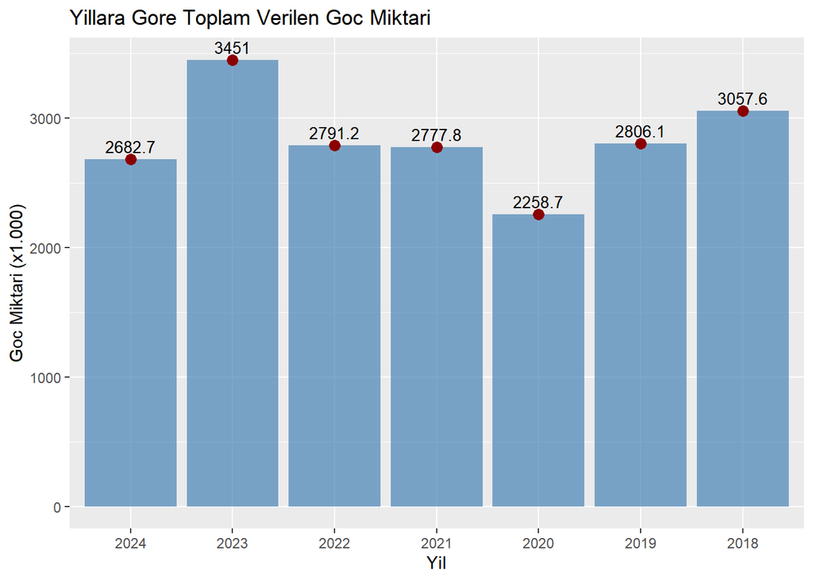

```r
yil <- factor(grafik_verisi[[1]], levels = sort(unique(grafik_verisi[[1]]), decreasing = TRUE))
goc_miktari  <- as.numeric(grafik_verisi[[3]])/1000

ggplot(data = grafik_verisi, aes(x = yil, y = goc_miktari)) +
  geom_col(fill = "steelblue", alpha = 0.7) +
  geom_line(color = "black", size = 2) +
  geom_point(color = "darkred", size = 3) +
  geom_text(aes(label = round(goc_miktari, 1)), vjust = -0.5, size = 3.5) +
  labs(
    title = "Yillara Gore Toplam Verilen Goc Miktari",
    x = "Yil",
    y = "Goc Miktari (x1.000)"
  )
```

If we examine migration trends between 2018 and 2024, we see that the lowest figure was recorded in 2020, the year of the pandemic. We can say that the curfews and prevailing uncertainty during that period may have prevented people from moving away from the cities where they lived. We also see that the highest increase occurred in 2023, as the Kahramanmaras earthquake struck in February 2023, prompting people to begin migrating to safer cities with lower earthquake risks. We also see a relatively high migration trend in 2018. During that period, due to the economic crisis and inflation in Turkiye, there was a migration trend from expensive metropolitan cities like Ankara and Istanbul to smaller cities.

### 3.1.2. Changes in Total Migration Values by Year for Ankara Provience

The graphic shows the changes in total migration amounts over the years for Ankara province.

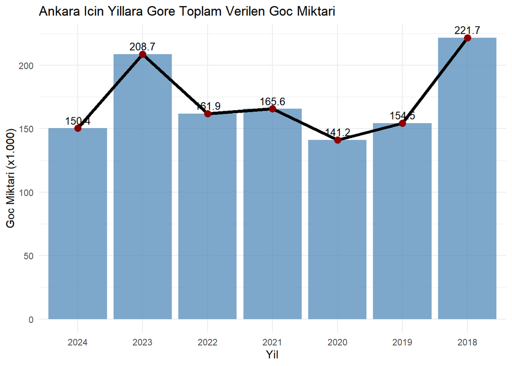

```r
library(ggplot2)

# 1. Ankara verisini filtreliyoruz
grafik_verisi <- VerilenGoc[VerilenGoc[, 2] == "Ankara", ]

# 2. Yeni degiskenleri tablonun disinda olusturmak yerine,
# dogrudan tabloya yeni sutun olarak ekliyoruz (ggplot'un en sevdigi yontem)
grafik_verisi$yil_farkli <- factor(grafik_verisi[[1]], levels = sort(unique(grafik_verisi[[1]]), decreasing = TRUE))
grafik_verisi$goc_bin <- as.numeric(grafik_verisi[[3]]) / 1000

# 3. Grafigi cizdiriyoruz (Artik eksenler tablonun icindeki yeni sutunlari goruyor)
ggplot(data = grafik_verisi, aes(x = yil_farkli, y = goc_bin, group = 1)) +
  geom_col(fill = "steelblue", alpha = 0.7) +
  geom_line(color = "black", linewidth = 1.5) + # size yerine yenilenen linewidth kullanildi
  geom_point(color = "darkred", size = 3) +
  geom_text(aes(label = round(goc_bin, 1)), vjust = -0.5, size = 3.5) +
  theme_minimal() + # Daha temiz bir gorunum ekledik
  labs(
    title = "Ankara Icin Yillara Gore Toplam Verilen Goc Miktari",
    x = "Yil",
    y = "Goc Miktari (x1.000)"
  )
```

### 3.1.3. Migration Figures by Province in 2024

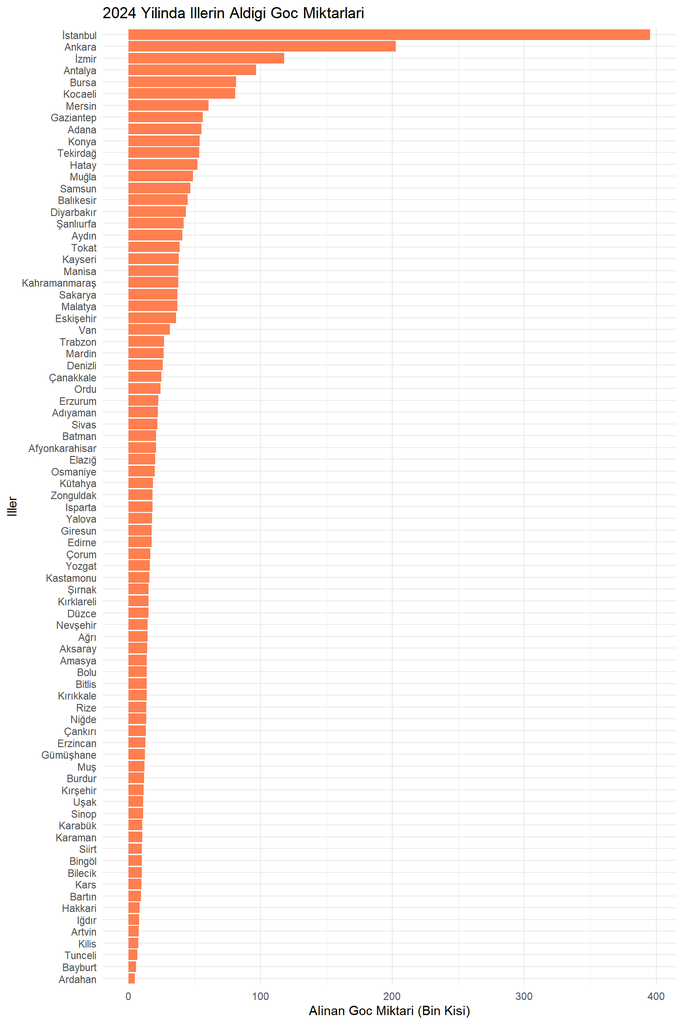

```r
AlinanGoc  <- read_excel("C:/emu660-spring2026-burcubaris/AlinanGoc.xlsx",col_names = TRUE)

colnames(AlinanGoc)[1:3] <- c("Yil", "Il", "Goc_Miktari")
veri_2024 <- subset(AlinanGoc, Yil == 2024 & Il != "Toplam-Total")
veri_2024$Goc_Miktari_Bin <- veri_2024$Goc_Miktari / 1000


ggplot(veri_2024, aes(x = Goc_Miktari_Bin, y = reorder(Il, Goc_Miktari_Bin))) +
  geom_col(aes(fill = Goc_Miktari_Bin > 0)) +
  scale_fill_manual(values = c("coral", "skyblue"), guide = "none") +
  theme_minimal() +
  labs(
    title = "2024 Yilinda Illerin Aldigi Goc Miktarlari",
    x = "Alinan Goc Miktari (Bin Kisi)",
    y = "Iller"
  )
```

### 3.1.4. Net Migration Figures of Provinces in 2024

A graphical representation of the calculation made using the previously calculated data given migration-received migration data.

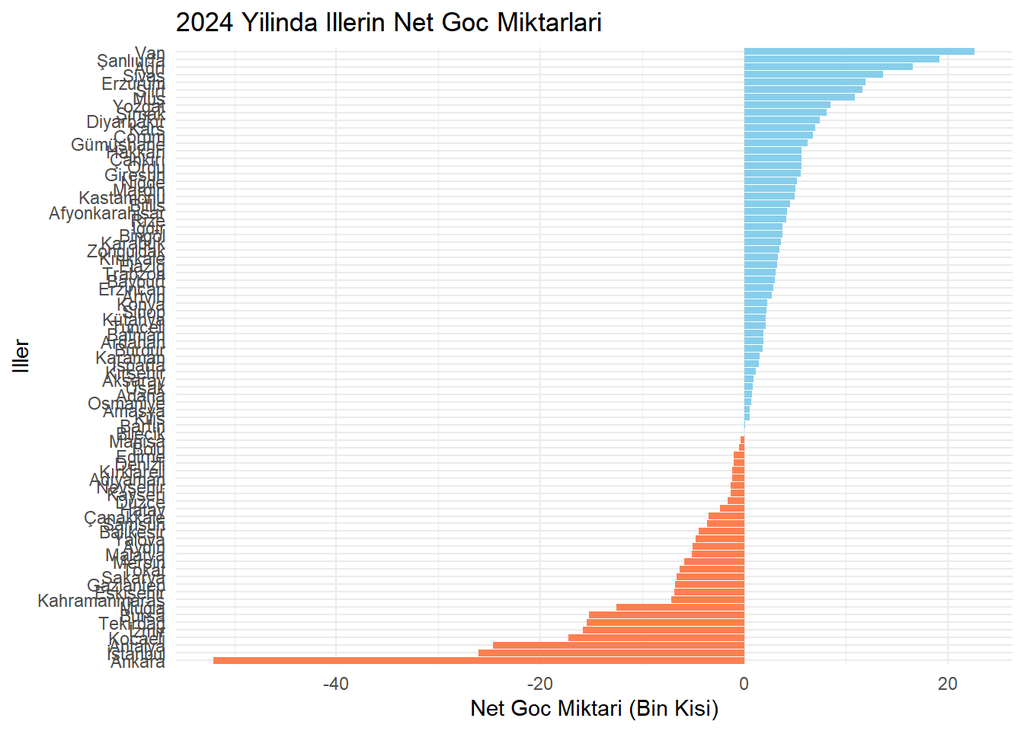

```r
NetGoc  <- read_excel("C:/emu660-spring2026-burcubaris/NetGoc.xlsx",col_names = TRUE)

colnames(NetGoc)[1:3] <- c("Yil", "Il", "Goc_Miktari")
veri_2024 <- subset(NetGoc, Yil == 2024 & Il != "Toplam-Total")
veri_2024$Goc_Miktari_Bin <- veri_2024$Goc_Miktari / 1000


ggplot(veri_2024, aes(x = Goc_Miktari_Bin, y = reorder(Il, Goc_Miktari_Bin))) +
  geom_col(aes(fill = Goc_Miktari_Bin > 0)) +
  scale_fill_manual(values = c("coral", "skyblue"), guide = "none") +
  theme_minimal() +
  labs(
    title = "2024 Yilinda Illerin Net Goc Miktarlari",
    x = "Net Goc Miktari (Bin Kisi)",
    y = "Iller"
  )
```

### 3.1.5. Graph showing the distribution of migration reasons that make up net migration data.

Migration reasons include: change of job, starting/finding a job, change of marital status/family-related reasons, better housing and living conditions, migration related to any member of the household/family, returning to family home/hometown, health/care, buying a house, retirement, other, and unknown.

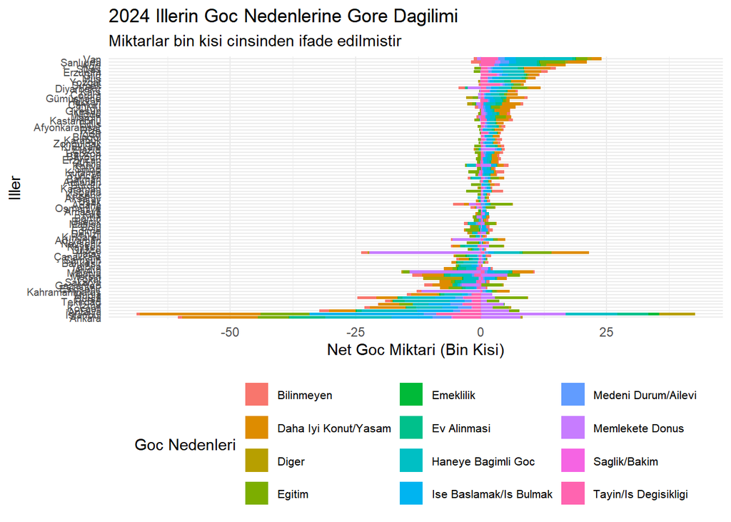

```r
NetGoc  <- read_excel("C:/emu660-spring2026-burcubaris/NetGoc.xlsx",col_names = TRUE)

goc_nedenleri <- c("Tayin/Is Degisikligi", "Ise Baslamak/Is Bulmak", "Egitim",
                   "Medeni Durum/Ailevi", "Daha Iyi Konut/Yasam", "Haneye Bagimli Goc",
                   "Memlekete Donus", "Saglik/Bakim", "Ev Alinmasi",
                   "Emeklilik", "Diger", "Bilinmeyen")

colnames(NetGoc)[1:3] <- c("Yil", "Il", "Toplam_Goc")
colnames(NetGoc)[4:15] <- goc_nedenleri
veri_2024 <- subset(NetGoc, Yil == 2024 & Il != "Toplam-Total")

veri_uzun <- pivot_longer(veri_2024,
                          cols = 4:15,
                          names_to = "Goc_Nedeni",
                          values_to = "Miktar")

veri_uzun$Miktar_Bin <- veri_uzun$Miktar / 1000

goc_grafigi <- ggplot(veri_uzun, aes(x = Miktar_Bin, y = reorder(Il, Toplam_Goc), fill = Goc_Nedeni)) +
  geom_col(position = "stack") +
  theme_minimal() +
  labs(
    title = "2024 Illerin Goc Nedenlerine Gore Dagilimi",
    subtitle = "Miktarlar bin kisi cinsinden ifade edilmistir",
    x = "Net Goc Miktari (Bin Kisi)",
    y = "Iller",
    fill = "Goc Nedenleri"
  ) +
  theme(
    legend.position = "bottom",
    legend.text = element_text(size = 8),
    axis.text.y = element_text(size = 7)
  ) +
  guides(fill = guide_legend(ncol = 3))

print(goc_grafigi)
```

## 3.2 Trend Analysis

The graph shows the relational analysis between migration rate data and life indices of the provinces.

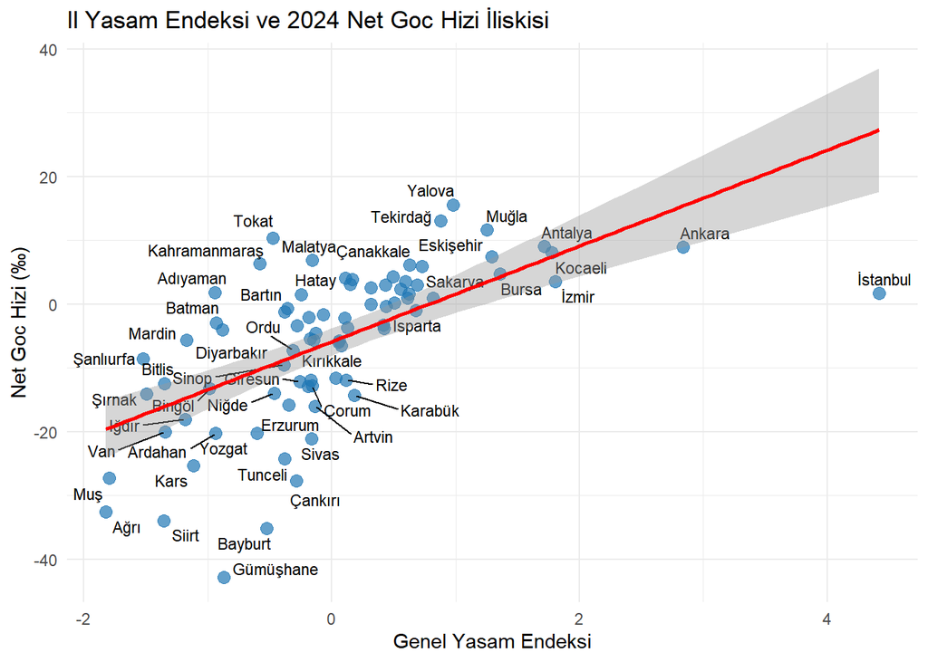

```r
yasam_df <- read_excel("C:/emu660-spring2026-burcubaris/YasamEndeksi.xlsx", col_names = TRUE)
goc_df <- read_excel("C:/emu660-spring2026-burcubaris/Gochizi.xlsx", col_names = TRUE)

colnames(yasam_df)[1:2] <- c("Il", "Endeks")
colnames(goc_df)[1:3]   <- c("Yil", "Il", "Goc")

goc_2024 <- subset(goc_df, Yil == 2024 & Il != "Toplam-Total")

veri_seti <- inner_join(yasam_df, goc_2024, by = "Il")

grafik <- ggplot(veri_seti, aes(x = Endeks, y = Goc, label = Il)) +
  geom_point(color = "#1f77b4", size = 3, alpha = 0.7) +
  geom_text_repel(size = 3, max.overlaps = 15) +
  geom_smooth(method = "lm", color = "red", se = TRUE, formula = y ~ x) +
  labs(
    title = "Il Yasam Endeksi ve 2024 Net Goc Hizi İliskisi",
    x = "Genel Yasam Endeksi",
    y = "Net Goc Hizi (‰)"
  ) +
  theme_minimal()

print(grafik)
```

## 3.3 Results

When we examine the graph, we see a positive correlation between the overall quality of life index and the net migration rate. It has been observed that provinces with a high quality of life index tend to attract more migration, while those with a low index tend to lose population. Developed provinces such as Istanbul, Ankara, Antalya, and Muğla have a positive net migration rate, while provinces such as Ağrı, Muş, Şırnak, and Kars stand out with negative net migration rates. However, the fact that the data points do not cluster entirely around the regression line indicates that migration patterns cannot be explained solely by the quality of life index and that other economic, social, and demographic factors also play a role.

# 4 Results and Key Takeaways

One of the project’s most significant findings was that migration decisions in Turkey are largely influenced by factors related to family and quality of life. According to the 2024 analysis of migration reasons, dependence on family and the search for better housing and living conditions were among the most significant driving forces behind migration. Education-related reasons also remained one of the most consistent motivations for migration throughout the 2018–2024 period, indicating that universities and educational opportunities significantly influence internal migration decisions.

Overall, the project demonstrates that internal migration in Turkey reflects regional disparities in development, the distribution of opportunities, and quality of life. Based on our findings, we believe that balanced regional development policies, investments in education and employment opportunities, and improvements to social infrastructure in underdeveloped provinces are essential for reducing forced migration and regional disparities.

Back to top